# R Notebook

# Stepwise calibration of lung cancer model with constraints

- 9 age groups, 11 parameters per age group: total of 99 parameters to be calibrated.
- 9 of those parameters (one per age group) are probabilities of developing cancer, with the constraint of these probabilities increasing with age.

|  | method | group | time | iterations | error | delay | constrained |
| --- | --- | --- | --- | --- | --- | --- | --- |
| 1 | nelder-mead | 1 | 86.21 | 839 | 0.16857872 | 0.100 | yes |
| 2 | nelder-mead | 2 | 79.72 | 775 | 0.16857872 | 0.100 | yes |
| 3 | nelder-mead | 3 | 81.66 | 793 | 0.16857872 | 0.100 | yes |
| 4 | nelder-mead | 4 | 101.61 | 985 | 0.21122801 | 0.100 | yes |
| 5 | nelder-mead | 5 | 128.52 | 1236 | 0.66454672 | 0.100 | yes |
| 6 | nelder-mead | 6 | 127.03 | 1233 | 1.97950782 | 0.100 | yes |
| 7 | nelder-mead | 7 | 231.11 | 2242 | 77.27794695 | 0.100 | yes |
| 8 | nelder-mead | 8 | 201.02 | 1948 | 81.39995534 | 0.100 | yes |
| 9 | nelder-mead | 9 | 288.74 | 2796 | 83.05701057 | 0.100 | yes |
| 10 | bo | 1 | 119.78 | 40 | 0.12373462 | 0.100 | yes |

[output cut: 80 more lines]

## **Overall results**

| method | constrained | total.iterations | total.time | final.error | sim.time | total.overhead |
| --- | --- | --- | --- | --- | --- | --- |
| annealing | no | 276693 | 28809.09 | 81.06351 | 0.100 | 1139.79 |
| annealing | yes | 283113 | 29501.15 | 82.86101 | 0.100 | 1189.85 |
| bo | no | 360 | 2083.25 | 83.24328 | 0.100 | 2047.25 |
| bo | yes | 360 | 3089.76 | 83.05360 | 0.100 | 3053.76 |
| bo.oak.20 | no | 180 | 26991.96 | 43.90502 | 0.001 | 26991.78 |
| bo.oak.20 | yes | 180 | 24672.36 | 50.49876 | 0.001 | 24672.18 |
| nelder-mead | no | 9447 | 985.95 | 81.25969 | 0.100 | 41.25 |
| nelder-mead | yes | 12847 | 1325.62 | 83.05701 | 0.100 | 40.92 |
| pso | no | 680595 | 70939.50 | 81.04074 | 0.100 | 2880.00 |
| pso | yes | 518656 | 54077.75 | 83.04491 | 0.100 | 2212.15 |

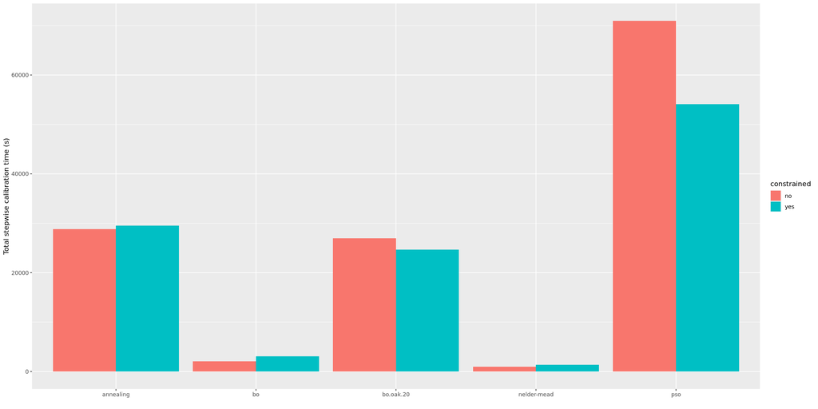

In absolute terms, calibration with BO using the stepwise method takes around **50 minutes**. Even the unconstrained version of the regular calibration proved to be unfeasible, requiring many days of computation while finding low-quality solutions. Adding constraints to the regular calibration would increase even further the computational cost of an already unfeasible problem.

## Calibration errors by age group

[output not shown]

## Calibrated parameters by age group

|  | method | param | value | constrained | error | distance |
| --- | --- | --- | --- | --- | --- | --- |
| 1 | initial | 1 | 0.03107 | yes | 0.00000 | 0.00000 |
| 2 | initial | 2 | 0.03107 | yes | 0.00000 | 0.00000 |
| 3 | initial | 3 | 0.03194 | yes | 0.00000 | 0.00000 |
| 4 | initial | 4 | 0.03195 | yes | 0.00000 | 0.00000 |
| 5 | initial | 5 | 0.03467 | yes | 0.00000 | 0.00000 |
| 6 | initial | 6 | 0.03739 | yes | 0.00000 | 0.00000 |
| 7 | initial | 7 | 0.04012 | yes | 0.00000 | 0.00000 |
| 8 | initial | 8 | 0.04082 | yes | 0.00000 | 0.00000 |
| 9 | initial | 9 | 0.04152 | yes | 0.00000 | 0.00000 |
| 10 | nelder-mead | 1 | 0.01554 | yes | -0.01553 | 0.01553 |

[output cut: 44 more lines]

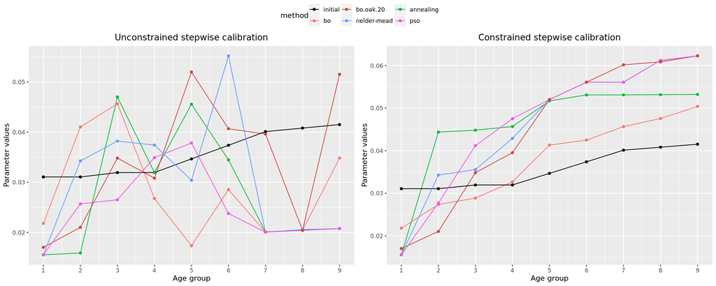

## Number of iterations per age group

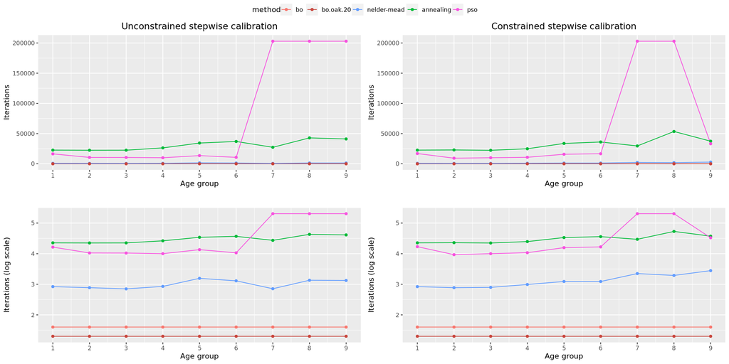

BO was run with a fixed budget of 40 iterations, including 10 random initial observations. Even though SA has a lower error we can see that it requires a very large number of iterations for a very modest improvement on the solution. PSO gets stuck in the last age groups and stops at the established maximum iterations.

## Critical simulation time for constrained stepwise calibration

[output not shown]

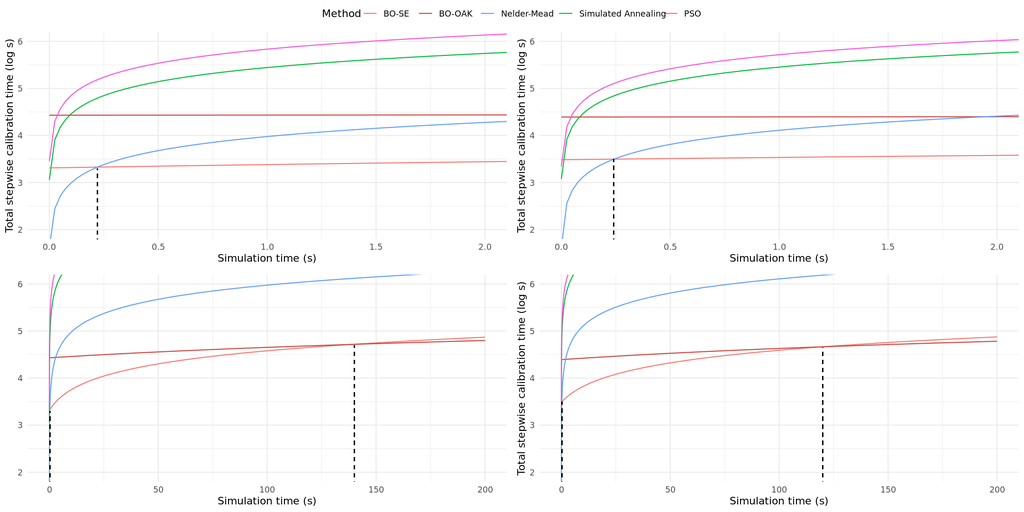

The critical simulation time for the whole model with all 9 age groups (that **we projected at 300 seconds using conventional calibration**) is reduced to **~0.24 seconds using constrained stepwise calibration with BO and a SE kernel (BO-SE)**.

- $t_{sim}$ < 0.24s: **Nelder-Mead**
- 0.24s < $t_{sim}$ < 120s: **BO-SE**
- $t_{sim}$ > 120s: **BO-OAK**

This proves that this method dramatically improves the efficiency of Bayesian Optimization, avoiding its major flaw (high dimensionality problems) by reducing the effective dimension of the calibration from one 99-parameter problem to nine 11-parameter problems.

The critical simulation time doesn’t change significantly when considering an unconstrained calibration using BO-SE, but there are differences between constrained and unconstrained calibration times using BO-OAK. In any case the critical time for BO-OAK at this time is higher than the current models that we are working on, so BO-SE remains the best option for our most time-consuming models.